# Project 4

ROC curve with true positive rate and false positive rate. true positive rate: percentage of purchased items that have been recommended. TP rate = TP/ (TP+FN). false postitive rate: percentage of not purchase items that have been recommened. FP rate = FP / (FP+TN)

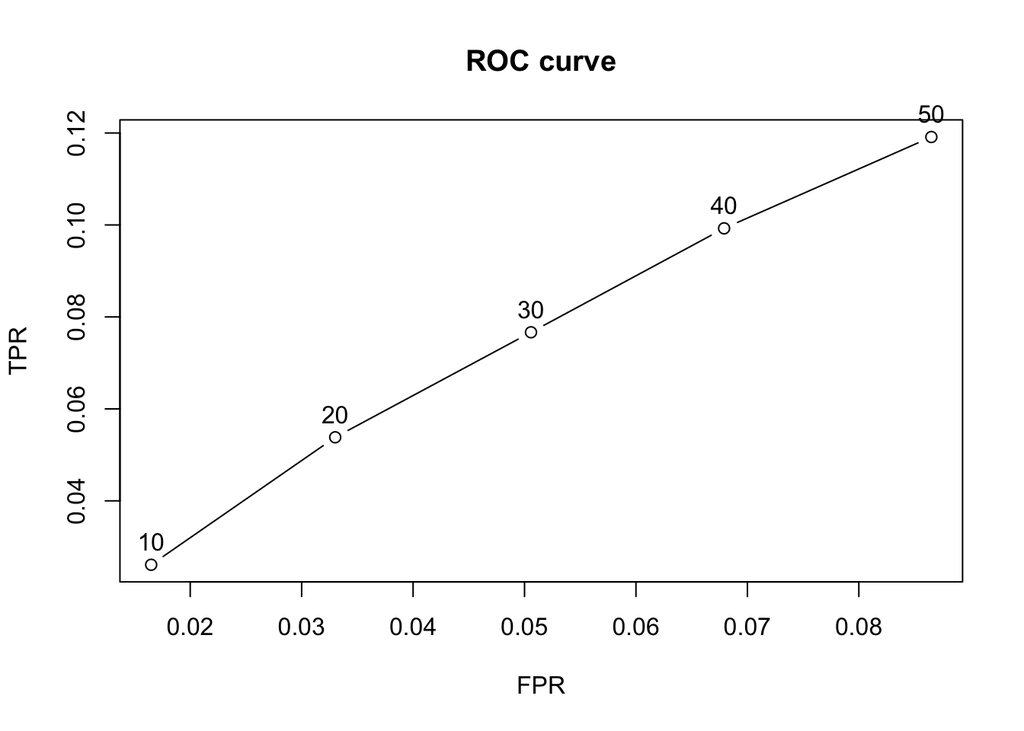

```r
plot(results, annotate = TRUE, main = "ROC curve")
```

Precision-recall curve with the rate of precision and recall.

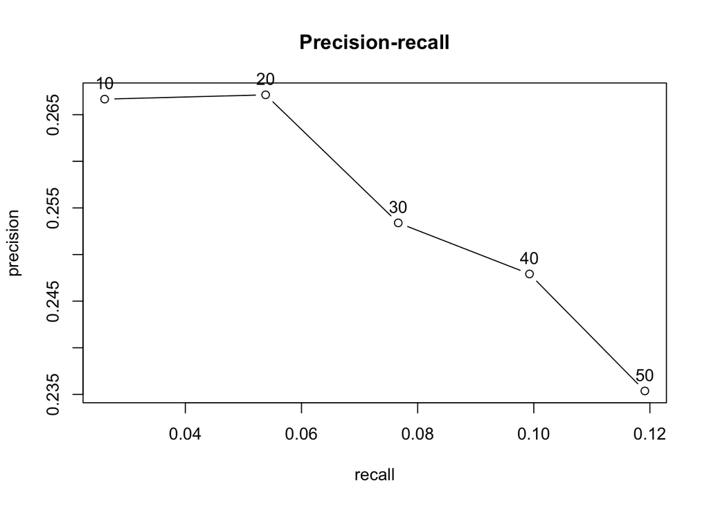

```r
plot(results,"prec/rec", annotate = TRUE, main="Precision-recall")
```

```r
models_to_evaluate <- list(
  IBCF_cos = list(name = "IBCF", param = list(method = "cosine")),
  IBCF_cor = list(name = "IBCF", param= list (method = "pearson")),
  UBCF_cos = list(name = "UBCF", param = list(method = "cosine")),
  UBCF_cor = list(name = "UBCF", param = list(method = "pearson")),
  random=list(name="RANDOM", param =NULL)
)
n_recommendations <- c (1,5, seq(10,50,10))
list_results <- evaluate(x = evaluation_set, method = models_to_evaluate, n = n_recommendations)
```

```
## IBCF run fold/sample [model time/prediction time]
##   1  [0.868sec/0.077sec]
## IBCF run fold/sample [model time/prediction time]
##   1  [0.93sec/0.057sec]
## UBCF run fold/sample [model time/prediction time]
##   1  [0.004sec/0.159sec]
## UBCF run fold/sample [model time/prediction time]
##   1  [0.003sec/0.177sec]
## RANDOM run fold/sample [model time/prediction time]
##   1  [0.001sec/0.047sec]
```

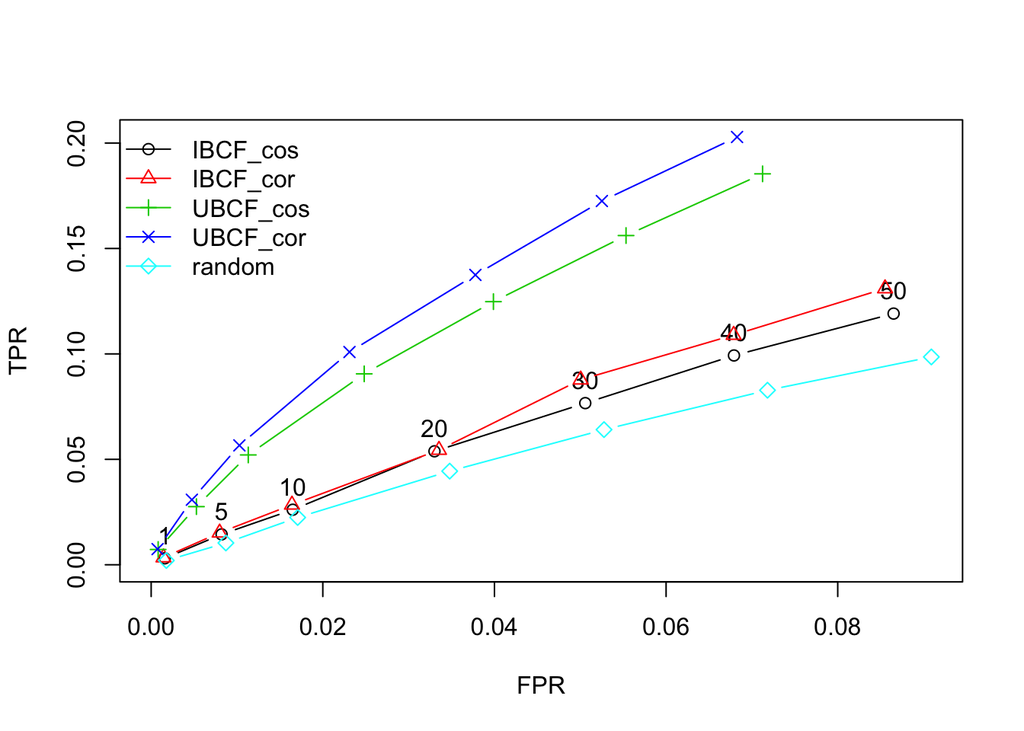

```r
plot(list_results,annotate = 1, legend = "topleft")
```

The highest AUC, the area under the ROC curve is from UBCF with pearson, so, in our case, UBCF_cor is the best-performing technique.

Optimizing k-value.

```r
vector_k <- c(5,10,20,30,40)
models_to_evaluate <- lapply(vector_k, function(k){
  list(name="IBCF",param = list(method = "cosine",k = k))
})
names(models_to_evaluate) <- paste0("IBCF_K_", vector_k)
n_recommendations <- c (1,5, seq(10,50,10))
list_results <- evaluate(x = evaluation_set, method = models_to_evaluate, n = n_recommendations)
```

```
## IBCF run fold/sample [model time/prediction time]
##   1  [0.877sec/0.027sec]
## IBCF run fold/sample [model time/prediction time]
##   1  [0.851sec/0.032sec]
## IBCF run fold/sample [model time/prediction time]
##   1  [0.842sec/0.044sec]
## IBCF run fold/sample [model time/prediction time]
##   1  [0.848sec/0.051sec]
## IBCF run fold/sample [model time/prediction time]
##   1  [0.727sec/0.061sec]
```

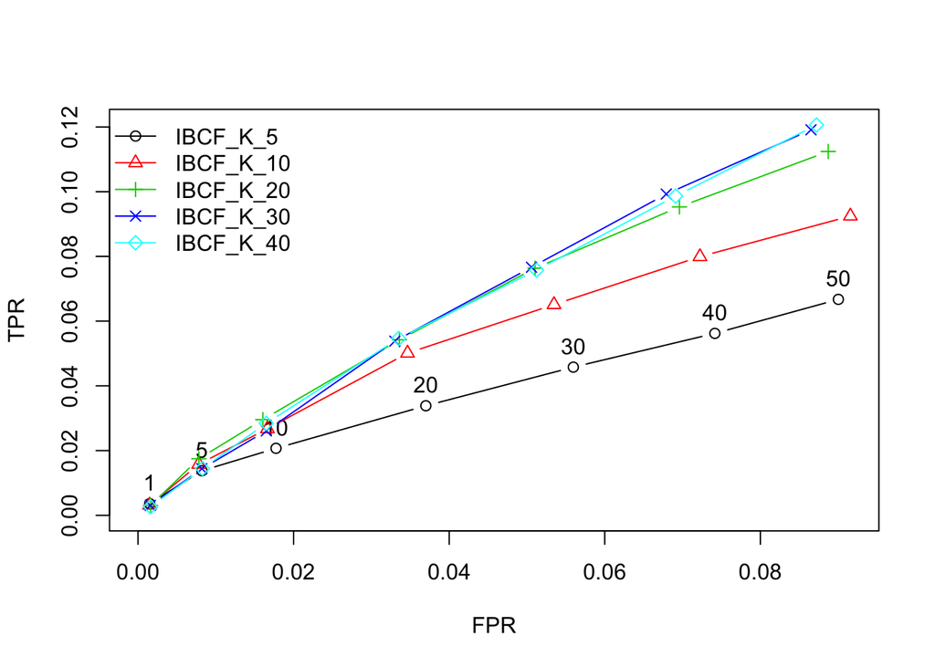

```r
plot(list_results,annotate = 1, legend = "topleft")
```

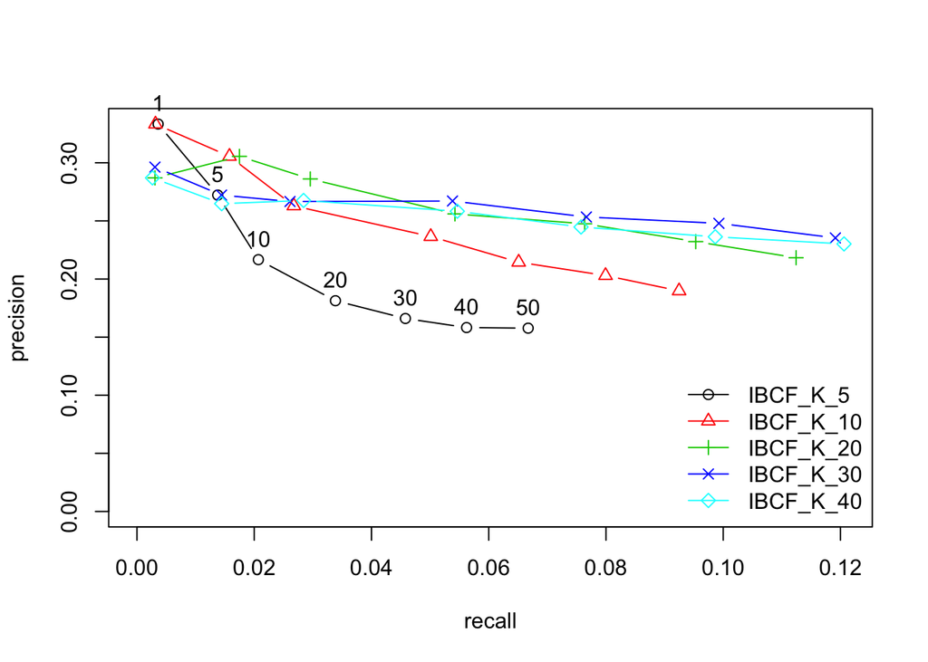

```r
plot(list_results,"prec/rec",annotate = 1, legend="bottomright")
```

The k having the biggest AUC is 40, the second one is 30. and if we want to fine the precision, we set k =20.

Now, I run the SVD, SVDF, and ALS algorithms for the recommender system.

```r
# Create the recommender based on SVD, SVDF, and ALS using the training data
r.svd <- Recommender(getData(evaluation_set, "train"),"SVD")
r.svdf <- Recommender(getData(evaluation_set, "train"),"SVDF")
r.als <- Recommender(getData(evaluation_set, "train"),"ALS")

#Compute predicted ratings for the test data.
p.svd <- predict(r.svd, getData(evaluation_set,"known"),type="ratings")
p.svdf <- predict(r.svdf,getData(evaluation_set,"known"),type="ratings")
p.als <- predict(r.als, getData(evaluation_set,"known"),type="ratings")

error <- rbind(svd = calcPredictionAccuracy(p.svd,getData(evaluation_set, "unknown")),
               svdf = calcPredictionAccuracy(p.svdf,getData(evaluation_set,"unknown")),
               als = calcPredictionAccuracy(p.als, getData(evaluation_set,"unknown")))
error
```

```
##           RMSE       MSE       MAE
## svd  0.9705659 0.9419982 0.7741054
## svdf 0.8741273 0.7640986 0.6842043
## als  0.8766665 0.7685441 0.6957556
```

From this error matrix, we find that svdf has the smallest RMSE and MAE.

```r
models_to_evaluate <- list(
  svd = list(name = "svd", param = list(method = "SVD",type="topNList")),
  svdf = list(name = "svdf", param= list (method = "SVDF",type="topNList")),
  als = list(name = "als", param = list(method = "ALS",type="topNList"))
)

n_recommendations <- c (1,5, seq(10,50,10))
list_results <- evaluate(x = evaluation_set, method = models_to_evaluate, n = n_recommendations)
```

```
## svd run fold/sample [model time/prediction time]
##   1
```

```
## Available parameter (with default values):
## k     =  10
## maxiter   =  100
## normalize     =  center
## verbose   =  FALSE
## [0.031sec/0.044sec]
## svdf run fold/sample [model time/prediction time]
##   1
```

```
## Available parameter (with default values):
## k     =  10
## gamma     =  0.015
## lambda    =  0.001
## min_epochs    =  50
## max_epochs    =  200
## min_improvement   =  1e-06
## normalize     =  center
## verbose   =  FALSE
## [14.761sec/5.33sec]
## als run fold/sample [model time/prediction time]
##   1
```

```
## Available parameter (with default values):
## normalize     =  NULL
## lambda    =  0.1
## n_factors     =  10
## n_iterations  =  10
## min_item_nr   =  1
## seed  =  NULL
## verbose   =  FALSE
## [0.001sec/7.645sec]
```